# FIFA World Cup Visualization: Data from 1930 - 2014

Bsc, Christopher Sianyo Maronga

29 November, 2018

# History of FIFA World cup

A game loved by many and full of emotions and reactions. The FIFA World Cup was first held in 1930, when FIFA president Jules Rimet decided to stage an international men’s football tournament. The inaugural edition, held in 1930, was contested as a final tournament of only thirteen teams invited by the organization

More on world cup history, click; [here](https://en.wikipedia.org/wiki/History_of_the_FIFA_World_Cup)

## 1. Number of teams Qualifying

Initially, only 13 teams contested this prestigious tournament. As the gamme grew in popularity, more and more countries/teams have been added to the list seing the number grow from 13 to 32 teams and with a possibility of the number of teams increasing to [48](http://kwese.espn.com/football/fifa-world-cup/story/3035778/fifa-council-unanimously-approves-world-cup-expansion-to-48-teams) according to FIFA council

The bar plot below shows total number of teams that participated in the tournament since 1930, increasing from 13 teams in 1930 to 32 teams currently

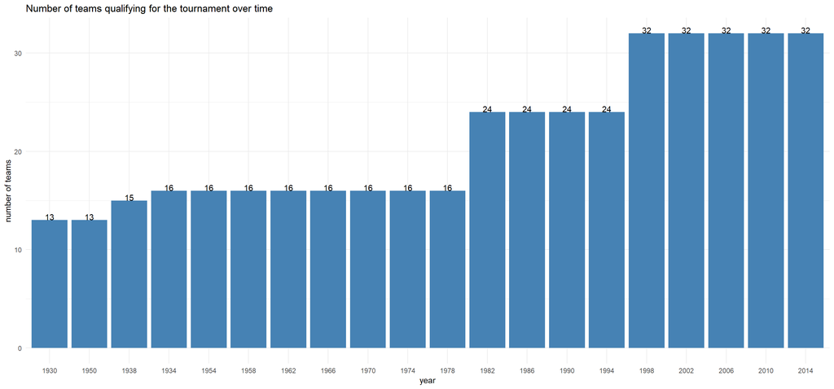

## 2. Tota number of matches played

The bar plot below summarizes the number of matches played over the evolution time of FIFA world cup

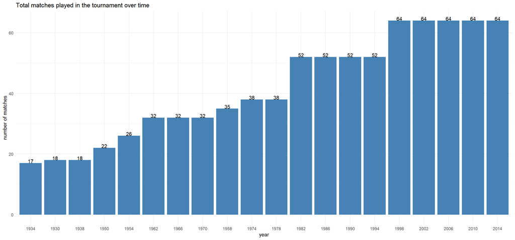

## 3. World Cup Winners since 1930

The endpoint of every competition or tournament is the emergence of a winner. There are only 9 countries who have ever won the FIFA world cup trophy with Brazil having won it the most(5 times) while Italy and Germany(Germany Federal Republic/Germany) winning it 4 times a piece.

The graph below shows the frequencies of FIFA world cup champions since 19930

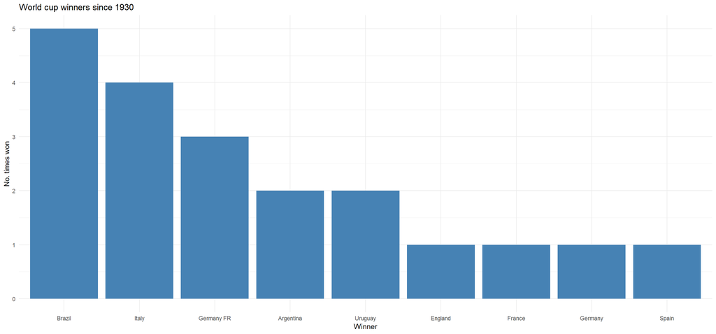

## 4. Champions over years since 1930

The rec plot below shows who the champion was for which year the tournament was held. Uruguy was the first team to win the FIFA world cup at home in 1930.

Only 2 countries, Italy(1934 & 1938) and Brazil(1958 & 1962) that have won the world cup back to back(Consectively). Uruguy is the only world cup champion with the longest spell since their last win(16 seasons), followed by England(12 season spell). Spain(2010) is the newest member on the list of FIFA world cup champions.

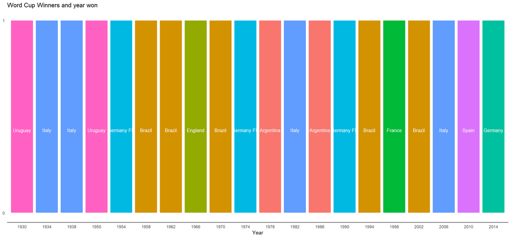

## 5. Total number of goals scored

Highest ever number of goals scored was in 1998 and 2014. 171 goals were scored

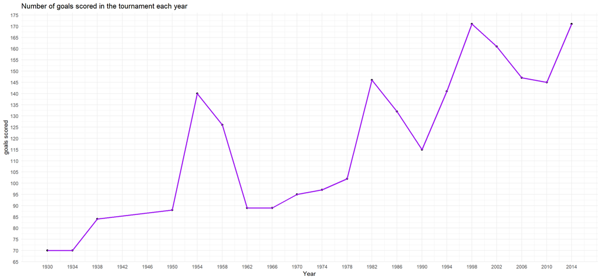

## 6. Cumulative number of goals scored

Upto the last time the tournament was held in Brazil in 2014, a total of 2379 goals have been scored cumulatively.

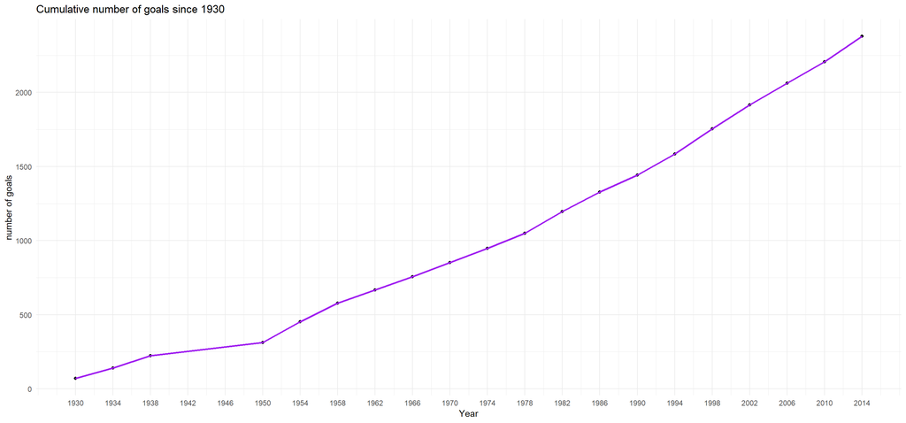

## 7. FIFA World Cup All time stadium attendance

A game loved by many cannot be played in an empty stadium or in some kind of a boardroom, the tournament has attracted hundreds of thousands of fans/lovers of the game over the years. The highest attendance recorded to be slightly 3.5 million fans in 1994 when it was held in the United States of America(USA) and the lowest attendance recorded in Sweeden in 1958.

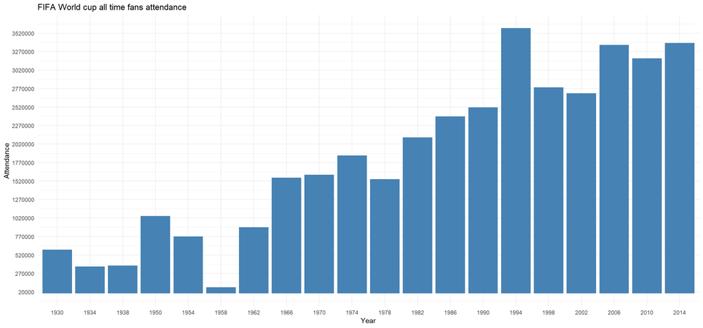

## 7. World cup hosts

| Country | Hosted |
| --- | --- |
| Argentina | 1 |
| Brazil | 2 |
| Chile | 1 |
| England | 1 |
| France | 2 |
| Germany | 2 |
| Italy | 2 |
| Korea/Japan | 1 |
| Mexico | 2 |
| South Africa | 1 |
| Spain | 1 |
| Sweden | 1 |
| Switzerland | 1 |
| Uruguay | 1 |
| USA | 1 |

## 7.1 World cup trophy winners at home

[output not shown]

## Remarks

This short visual analysis was a snipet of close to obvious facts about the FIFA world cup. With the available dataset, more analysis can be done to inform lovers of the game on the hidden statistics. For instance, is hosting the world cup increase your chances of winning?

The link below contains the dataset used in the. It is an open source data so feel free to use it to explore

[source of the dataset used in the analysis](https://www.kaggle.com/abecklas/fifa-world-cup)